# Measuring association

## Association = Probabilistic relationship

| Scenario | Formally | Implication (meaning) |
| --- | --- | --- |
| Independent | Pr(Y\|X) = Pr(Y) | Distibution of Y is equal for all X |
| Related | Pr(Y\|X) \(\ne\) Pr(Y) | Distribution of Y is NOT equal for all X |

Cases:

- X and Y are both categorical
- X and Y are both quantitative
- One of each type

## Independence

Distibution of Y is equal for all X

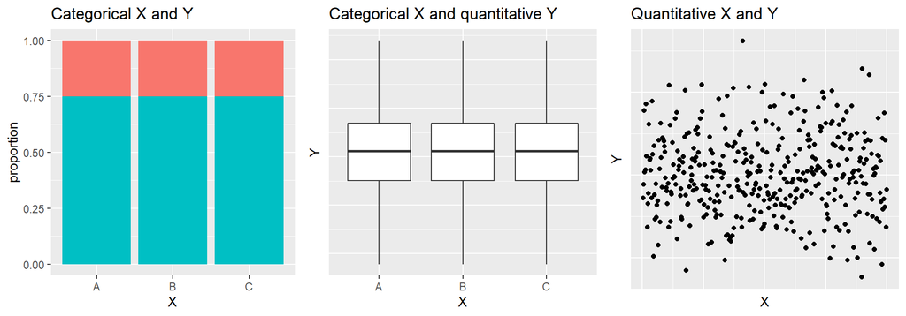

Any other pattern is non-independence (association)

## Association measures/analysis

| Variables | Measures/analysis |
| --- | --- |
| Quantitative (both) | covariance, correlation coefficients |
| Categorical (both) | chi-square, RD, RR, OR, NNT |
| One quantitative and one categorical | mean difference |

## Categorical X and Y

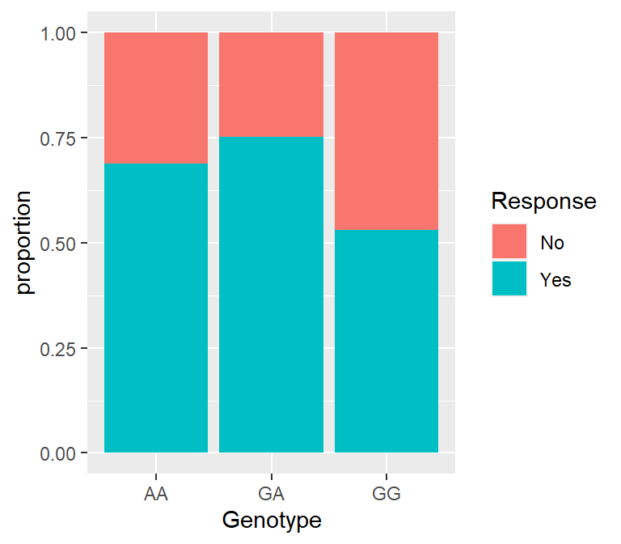

Contingency table

```
        Genotype
Response AA GA GG
     No  14 31 47
     Yes 31 94 53
```

Marginals (row and column totals)

```
        Genotype
Response  AA  GA  GG Sum
     No   14  31  47  92
     Yes  31  94  53 178
     Sum  45 125 100 270
```

## Expected in case of independence

```
        Genotype
Response  AA  GA  GG total
   No                   92
   Yes                 178
   total  45 125 100   270
```

- Overall probability of `Response = 178/270 =` `0.659`
- Apply it to each Genotype:
  - AA: `45 x 178/270 = 29.7`
  - AG: `125 x 178/270 = 82.4`
  - GG: `100 x 178/270 = 65.9`
- Similarly for `Non-response`

## Pearson’s chi-square (\(\chi^2\))

Observed (O)

```
        Genotype
Response AA GA GG
     No  14 31 47
     Yes 31 94 53
```

Expected (E)

```
        Genotype
Response   AA   GA   GG
     No  15.3 42.6 34.1
     Yes 29.7 82.4 65.9
```

\(\chi^2 = \sum\limits_{i=1}^{r \times c} \frac{(O_i - E_i)^2}{E_i} = 12.4\)

*Distance* from independence:

- Independence: \(\chi^2=0\)
- Association: \(\chi^2>0\)
  - the higher the \(\chi^2\) value, the stronger the association
  - but it also depends on the *degrees of freedom*: \((r-1) \times (c-1)\)

\(r\) rows and \(c\) columns

## Tables 2 \(\times\) 2: \(\quad\) RD, RR, and NNT

```
            group_A group_B
Success (S)      75      50
Failure (F)      25      50
Total           100     100

P(S)            .75     .50
```

Derived from **proportions** of **success** \(P_S\):

- Risk difference (RD): \(\quad P_{S|A} - P_{S|B} = 0.75 - 0.50 = 0.25\)
- Relative risk (RR): \(\quad \frac{P_{S|A}}{P_{S|B}} = \frac{0.75}{0.50} = 1.5\)
- Number needed to treat (NNT): \(\quad \frac{1}{\text{RD}} = \frac{1}{0.25} = 4\)

## Tables 2 \(\times\) 2: \(\quad\) OR

```
            group_A group_B
Success (S)      75      50
Failure (F)      25      50
Total           100     100

P(S)            .75     .50
O(S)              3       1
```

Derived from **odds** of **success** \(O_S\):

- Odds ratio (OR): \(\frac{O_{S|A}}{O_{S|B}} = \frac{3}{1} = 3\)

Note this equals cross product:

\(\frac{O_{S|A}}{O_{S|B}} = \frac{75/25}{50/50} = \frac{75 \times 50}{25 \times 50} = 3\)

## Categorical X and quantitative Y

Weight at birth (grams) and smoking during pregnancy

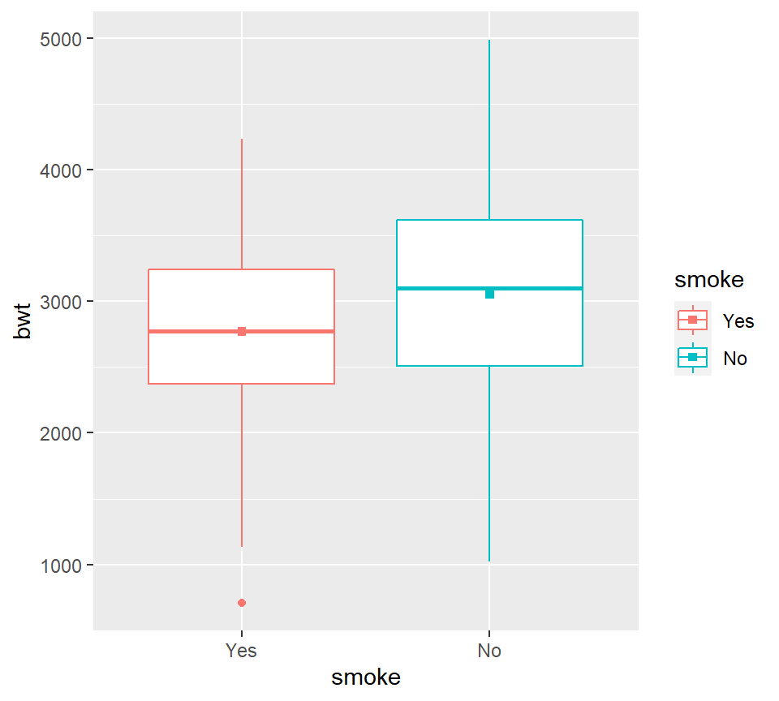

```
Means per group:
```

```
  smoke  bwt
1   Yes 2772
2    No 3056
```

```
Mean difference: 3056 - 2772 = 284 grams
```

## Quantitative X and Y: Covariance

Differences wrt the mean of each variable

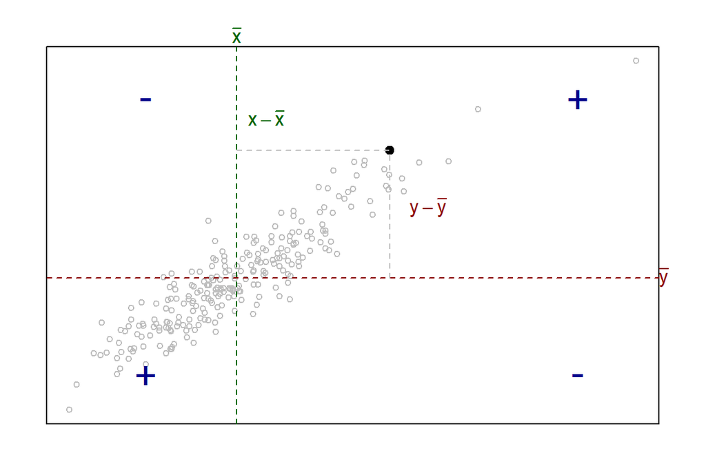

Covariance(X,Y) = \(\frac{1}{n} \sum{(x-\bar{x}) \times (y-\bar{y})}\)

## Covariance

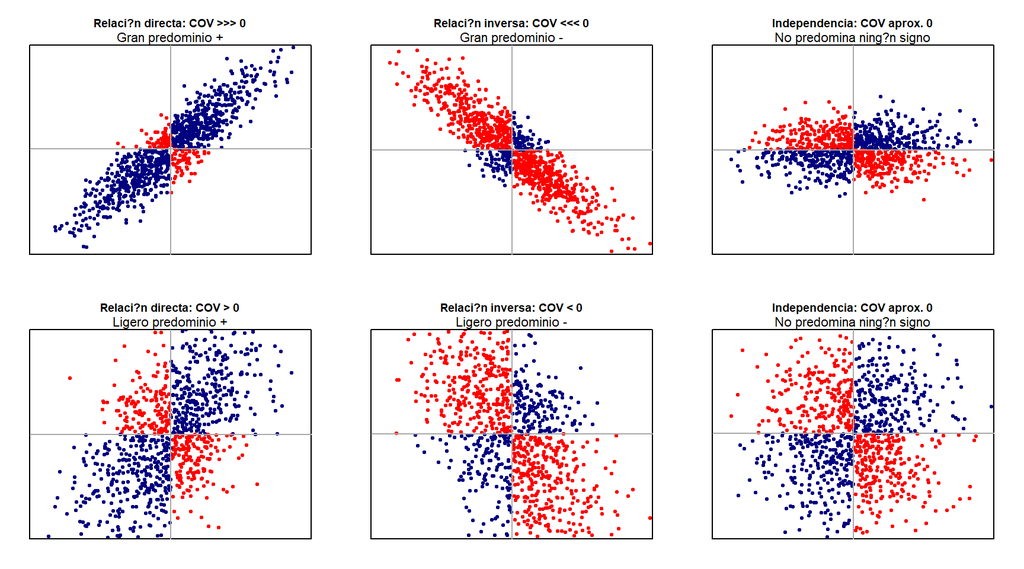

## Correlation coefficients

Measure *linear* relation (not *any* relation!):

- Pearson’s \(r\): \(\quad \frac{Cov(X,Y)}{S_X S_Y}\)
- Spearman’s \(r_s\): \(\quad\) Pearson’s \(r\) of the *ranks* of X and Y

For both, range is -1 to +1

Care with non-linearities and outliers, ALWAYS inspect scatterplot:

- linear with no outliers: Pearsons \(r\)
- outliers, or non-linear but *monotonic*: Spearman’s \(r_s\)
- non-linear, non-monotonic: neither!

## Patterns of relationship

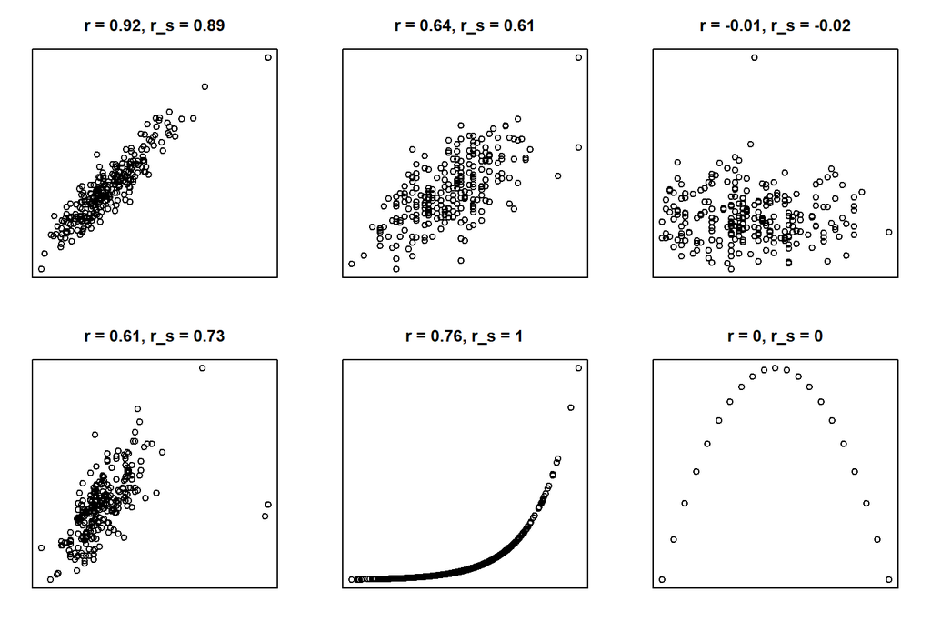